# Dictionary Methods and Sentiment Analysis

Rochelle Terman

August 2015

### Required Packages

```r
rm(list=ls())
setwd("~/Dropbox/berkeley/Git-Repos/text-analysis-dhbsi")

library(ggplot2) # plotting discourse data
library(qdap) # quantiative discourse analysis of transcripts
library(data.table) # for easier data manipulation
library(scales) # to help us plot
```

The `qdap`(Rinker, 2014) package provides an extensive suite of functions to support the quantitative analysis of text.

The package was originally intended to analyze transcript data. So the data must be in a particular format, namely a tabular spreadsheet with a `text` variable and some kind of `speaker` or metadata variable. The `text` variable must be in the form of sentences, with each sentence ending with punctuation: `.` , `?`, `!`.

`qdap` has an [extensive vignette](https://dl.dropboxusercontent.com/u/61803503/packages/qdap_vignette.html) that will help guide you through its requirements and functionality.

## 1. Comparing Songs on the Thriller Album

Let’s start with a simple example using lyrics from Michael Jackson’s Thriller album.

```r
# load data
thriller <- read.csv("Data/thriller.csv")

# see a truncated version of the data
head(truncdf(thriller),10)
```

```
##          Song      Lyrics
## 1  Wanna Be S \nI Said Yo
## 2  Baby Be Mi  I Don't Ne
## 3  The Girl I \nEvery Nig
## 4    Thriller  It's close
## 5     Beat It  They told
## 6  Billie Jea  She was mo
## 7  Human Natu  Looking Ou
## 8  PYT (Prett  Where Did
## 9  The Lady I  There'll b
## 10   Carousel  She's from
```

```r
# split the data into sentences (or, in this case, lines in the songs)
thril.split <- sentSplit(thriller, "Lyrics")
head(truncdf(thril.split),10)
```

```
##          Song  tot     Lyrics
## 1  Wanna Be S  1.1 I Said You
## 2  Wanna Be S  1.2 You Got To
## 3  Wanna Be S  1.3 I Said You
## 4  Wanna Be S  1.4 You Got To
## 5  Wanna Be S  1.5 It's Too H
## 6  Wanna Be S  1.6 Too Low To
## 7  Wanna Be S  1.7 You're Stu
## 8  Wanna Be S  1.8 And The Pa
## 9  Wanna Be S  1.9 It's Too H
## 10 Wanna Be S 1.10 Too Low To
```

The `qdap` package is great for using dictionary methods to analyze text. One of the most popular of these menthods is sentiment analysis, which calculates how “positive” or “negative” text is.

In `qdap`, we analyze sentiment using the `polarity` function.

```r
# calculate polarity
(poldat <- with(thril.split, polarity(Lyrics, Song)))
```

```
##                           Song total.sentences total.words ave.polarity sd.polarity stan.mean.polarity
## 1                 Baby Be Mine              48         360        0.067       0.200              0.336
## 2                      Beat It              37         289        0.200       0.313              0.638
## 3                  Billie Jean              53         451       -0.021       0.266             -0.081
## 4                     Carousel              50         215       -0.084       0.238             -0.353
## 5                 Human Nature              45         221        0.028       0.194              0.143
## 6     PYT (Pretty Young Thing)              65         310        0.233       0.334              0.700
## 7             The Girl Is Mine              53         325        0.050       0.239              0.211
## 8          The Lady In My Life              78         602        0.151       0.255              0.591
## 9                     Thriller              49         391       -0.137       0.250             -0.549
## 10 Wanna Be Startin' Somethin'             109         716       -0.097       0.189             -0.513
```

```r
# have a peak of each line
counts(poldat)[1:10,]
```

```
##                           Song wc polarity pos.words neg.words                                text.var
## 1  Wanna Be Startin' Somethin'  7    0.000         -         - I Said You Wanna Be Startin' Somethin'.
## 2  Wanna Be Startin' Somethin'  6    0.000         -         -       You Got To Be Startin' Somethin'.
## 3  Wanna Be Startin' Somethin'  7    0.000         -         - I Said You Wanna Be Startin' Somethin'.
## 4  Wanna Be Startin' Somethin'  6    0.000         -         -       You Got To Be Startin' Somethin'.
## 5  Wanna Be Startin' Somethin'  8    0.000         -         -   It's Too High To Get Over Yeah, Yeah.
## 6  Wanna Be Startin' Somethin'  7    0.000         -         -        Too Low To Get Under Yeah, Yeah.
## 7  Wanna Be Startin' Somethin'  7   -0.378         -     stuck  You're Stuck In The Middle Yeah, Yeah.
## 8  Wanna Be Startin' Somethin'  7   -0.378         -      pain     And The Pain Is Thunder Yeah, Yeah.
## 9  Wanna Be Startin' Somethin'  8    0.000         -         -   It's Too High To Get Over Yeah, Yeah.
## 10 Wanna Be Startin' Somethin'  7    0.000         -         -        Too Low To Get Under Yeah, Yeah.
```

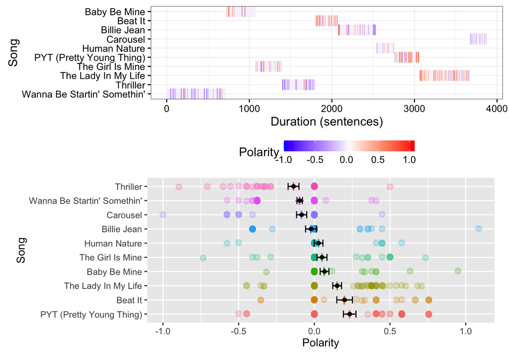

```r
# plot
plot(poldat)
```

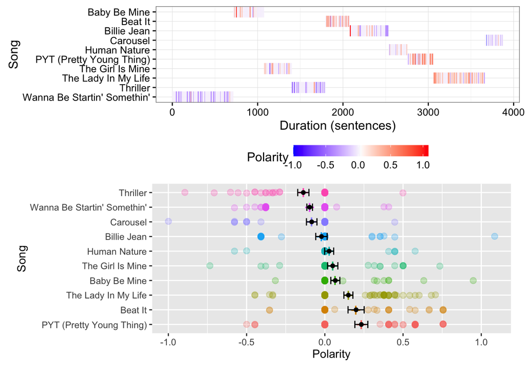

```r
# we can get just the second plot this way:
x <- plot(poldat)
```

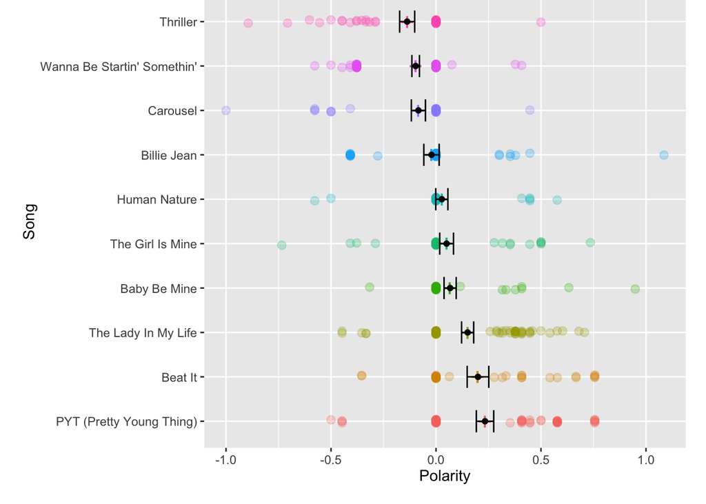

```r
x$p2
```

## 2. Visualizing Plot using Sentiments

`qdap` also has several datasets pre-formatted to help you explore. Let’s conduct a plot analysis of Romeo and Juliet using sentiments.

```r
# take a look at the data
head(truncdf(rajSPLIT),10)
```

```
##     person tot act sex fam.aff  died   dialogue  stem.text
## 1  Sampson 1.1   1   m     cap FALSE Gregory, o Gregori o
## 2  Gregory 2.1   1   m     cap FALSE No, for th No for the
## 3  Sampson 3.1   1   m     cap FALSE I mean, an I mean an
## 4  Gregory 4.1   1   m     cap FALSE Ay, while  Ay while y
## 5  Sampson 5.1   1   m     cap FALSE I strike q I strike q
## 6  Gregory 6.1   1   m     cap FALSE But thou a But thou a
## 7  Sampson 7.1   1   m     cap FALSE A dog of t A dog of t
## 8  Gregory 8.1   1   m     cap FALSE To move is To move is
## 9  Gregory 8.2   1   m     cap FALSE therefore, Therefor i
## 10 Sampson 9.1   1   m     cap FALSE A dog of t A dog of t
```

```r
# put that into a data.table
raj.dat <- data.table(rajSPLIT)
```

Now that we have the data, we can add columns for cumulative word counts and polarity scores. This will allow us to capture sentiments over “time.”

```r
# add word counts
raj.dat[, wc := wc(dialogue,missing=0)]
```

```
##         person  tot act sex fam.aff  died
##    1:  Sampson  1.1   1   m     cap FALSE
##    2:  Gregory  2.1   1   m     cap FALSE
##    3:  Sampson  3.1   1   m     cap FALSE
##    4:  Gregory  4.1   1   m     cap FALSE
##    5:  Sampson  5.1   1   m     cap FALSE
##   ---
## 2147: Montague 86.2   5   m    mont FALSE
## 2148:  Capulet 87.1   5   f     cap FALSE
## 2149:   Prince 88.1   5   m   escal FALSE
## 2150:   Prince 88.2   5   m   escal FALSE
## 2151:   Prince 88.3   5   m   escal FALSE
##                                                                                                                                                                dialogue
##    1:                                                                                                                        Gregory, o my word, we'll not carry coals.
##    2:                                                                                                                               No, for then we should be colliers.
```

[output cut: 33 more lines]

```r
# Add cumulative word count and percent complete as proxy for progression
raj.dat[, cumsum := cumsum(wc)]
```

```
##         person  tot act sex fam.aff  died
##    1:  Sampson  1.1   1   m     cap FALSE
##    2:  Gregory  2.1   1   m     cap FALSE
##    3:  Sampson  3.1   1   m     cap FALSE
##    4:  Gregory  4.1   1   m     cap FALSE
##    5:  Sampson  5.1   1   m     cap FALSE
##   ---
## 2147: Montague 86.2   5   m    mont FALSE
## 2148:  Capulet 87.1   5   f     cap FALSE
## 2149:   Prince 88.1   5   m   escal FALSE
## 2150:   Prince 88.2   5   m   escal FALSE
## 2151:   Prince 88.3   5   m   escal FALSE
##                                                                                                                                                                dialogue
##    1:                                                                                                                        Gregory, o my word, we'll not carry coals.
##    2:                                                                                                                               No, for then we should be colliers.
```

[output cut: 33 more lines]

```r
raj.dat[, pct.complete := raj.dat$cumsum / sum(raj.dat$wc)]
```

```
##         person  tot act sex fam.aff  died
##    1:  Sampson  1.1   1   m     cap FALSE
##    2:  Gregory  2.1   1   m     cap FALSE
##    3:  Sampson  3.1   1   m     cap FALSE
##    4:  Gregory  4.1   1   m     cap FALSE
##    5:  Sampson  5.1   1   m     cap FALSE
##   ---
## 2147: Montague 86.2   5   m    mont FALSE
## 2148:  Capulet 87.1   5   f     cap FALSE
## 2149:   Prince 88.1   5   m   escal FALSE
## 2150:   Prince 88.2   5   m   escal FALSE
## 2151:   Prince 88.3   5   m   escal FALSE
##                                                                                                                                                                dialogue
##    1:                                                                                                                        Gregory, o my word, we'll not carry coals.
##    2:                                                                                                                               No, for then we should be colliers.
```

[output cut: 33 more lines]

```r
raj.dat[, pct.complete.100 := pct.complete * 100]
```

```
##         person  tot act sex fam.aff  died
##    1:  Sampson  1.1   1   m     cap FALSE
##    2:  Gregory  2.1   1   m     cap FALSE
##    3:  Sampson  3.1   1   m     cap FALSE
##    4:  Gregory  4.1   1   m     cap FALSE
##    5:  Sampson  5.1   1   m     cap FALSE
##   ---
## 2147: Montague 86.2   5   m    mont FALSE
## 2148:  Capulet 87.1   5   f     cap FALSE
## 2149:   Prince 88.1   5   m   escal FALSE
## 2150:   Prince 88.2   5   m   escal FALSE
## 2151:   Prince 88.3   5   m   escal FALSE
##                                                                                                                                                                dialogue
##    1:                                                                                                                        Gregory, o my word, we'll not carry coals.
##    2:                                                                                                                               No, for then we should be colliers.
```

[output cut: 33 more lines]

```r
# calculate polarity
poldat.raj <- with(rajSPLIT, polarity(dialogue, act, constrain = TRUE))
counts(poldat.raj)[1:10,]
```

```
##    act wc polarity pos.words neg.words                                             text.var
## 1    1  8    0.000         -         -           Gregory, o my word, we'll not carry coals.
## 2    1  7    0.000         -         -                  No, for then we should be colliers.
## 3    1  9    0.000         -         -              I mean, an we be in choler, we'll draw.
## 4    1 11    0.000         -         - Ay, while you live, draw your neck out o the collar.
## 5    1  5   -0.220         -    strike                       I strike quickly, being moved.
## 6    1  8    0.175         -    strike            But thou art not quickly moved to strike.
## 7    1  9    0.000         -         -             A dog of the house of Montague moves me.
## 8    1 12    0.143   valiant         -   To move is to stir; and to be valiant is to stand.
## 9    1  8    0.000         -         -     therefore, if thou art moved, thou runn'st away.
## 10   1 10    0.000         -         -          A dog of that house shall move me to stand.
```

```r
polcount.raj <- na.omit(counts(poldat.raj)$polarity) # get vector of just the polarity scores

# put it into a data frame
len <- length(polcount.raj)
pol.df.raj <- data.frame(polarity = polcount.raj, Time=1:len)
```

Let’s plot it.

```r
## Calculate background rectangles for RAJ
ends <- cumsum(rle(counts(poldat.raj)$act)$lengths)
ends
```

```
## [1]  508  960 1549 1860 2151
```

```r
starts <- c(1, head(ends + 1, -1))
starts
```

```
## [1]    1  509  961 1550 1861
```

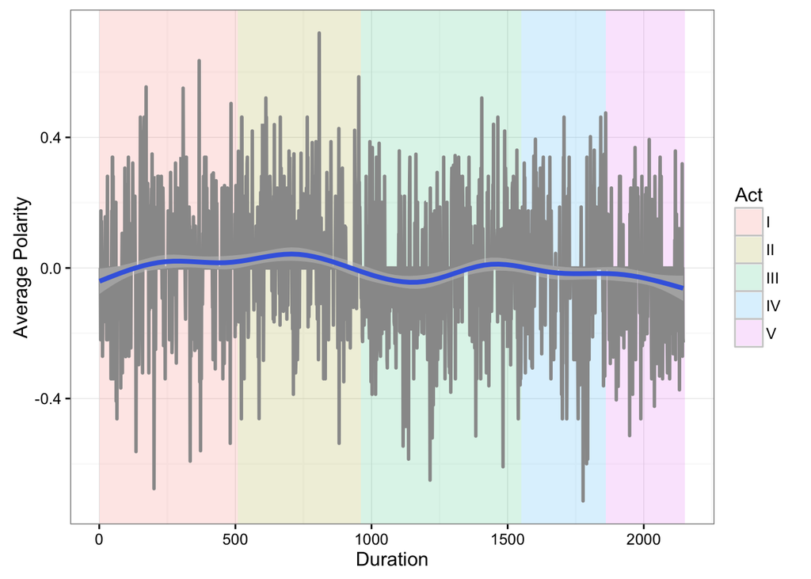

```r
rects <- data.frame(xstart = starts, xend = ends + 1,
                    Act = c("I", "II", "III", "IV", "V"))

# Plot RAJ
ggplot() + theme_bw() +
  geom_rect(data = rects, aes(xmin = xstart, xmax = xend,
                              ymin = -Inf, ymax = Inf, fill = Act), alpha = 0.17) +
  geom_line(data = pol.df.raj, aes(y=polarity, x = Time), size=1, color = "grey60") +
  geom_smooth(data = pol.df.raj, aes(y=polarity, x = Time), color="royalblue", fill="lightgray", size=1.4) +
  ylab("Average Polarity") + xlab("Duration")
```

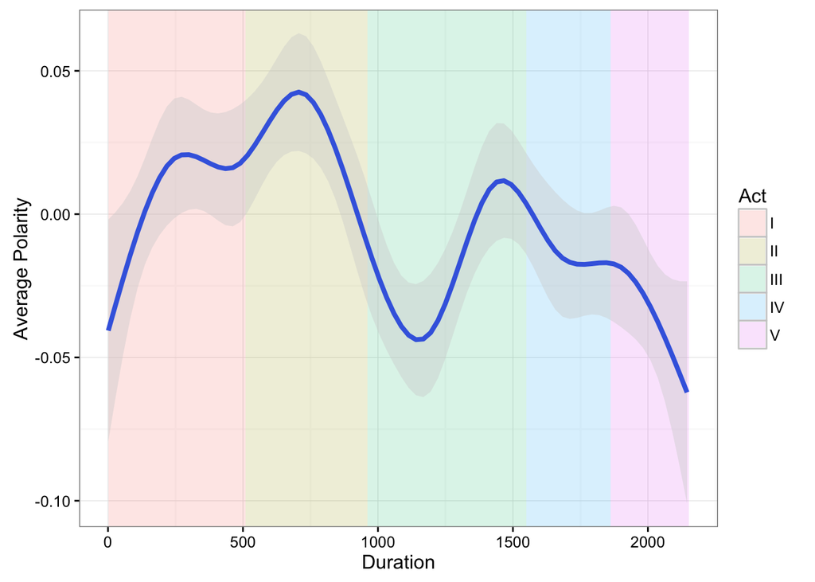

```r
# Zoom in on that smoothed line:

ggplot() + theme_bw() +
  geom_rect(data = rects, aes(xmin = xstart, xmax = xend,
                              ymin = -Inf, ymax = Inf, fill = Act), alpha = 0.17) +
  #geom_line(data = pol.df.raj, aes(y=polarity, x = Time), size=1, color = "grey60") +
  geom_smooth(data = pol.df.raj, aes(y=polarity, x = Time), color="royalblue", fill="lightgray", size=1.4) +
  ylab("Average Polarity") + xlab("Duration")
```

## 4. Bonus: More on QDAP

Besides polarity, `qdap` has other dictionaries to measure language formality, diversity, readability, etc. It also carries a range of tools to analyze and visualize discourse data, word usage, character usage, parts of speech, etc.

```r
# gantt plots
dat <- gantt(rajSPLIT$dialogue, rajSPLIT$person)
head(dat, 12)
```

```
##     person  n start end
## 1  Sampson  8     0   8
## 2  Gregory  7     8  15
## 3  Sampson  9    15  24
## 4  Gregory 11    24  35
## 5  Sampson  5    35  40
## 6  Gregory  8    40  48
## 7  Sampson  9    48  57
## 8  Gregory 20    57  77
## 9  Sampson 22    77  99
## 10 Gregory 13    99 112
## 11 Sampson 30   112 142
## 12 Gregory 10   142 152
```

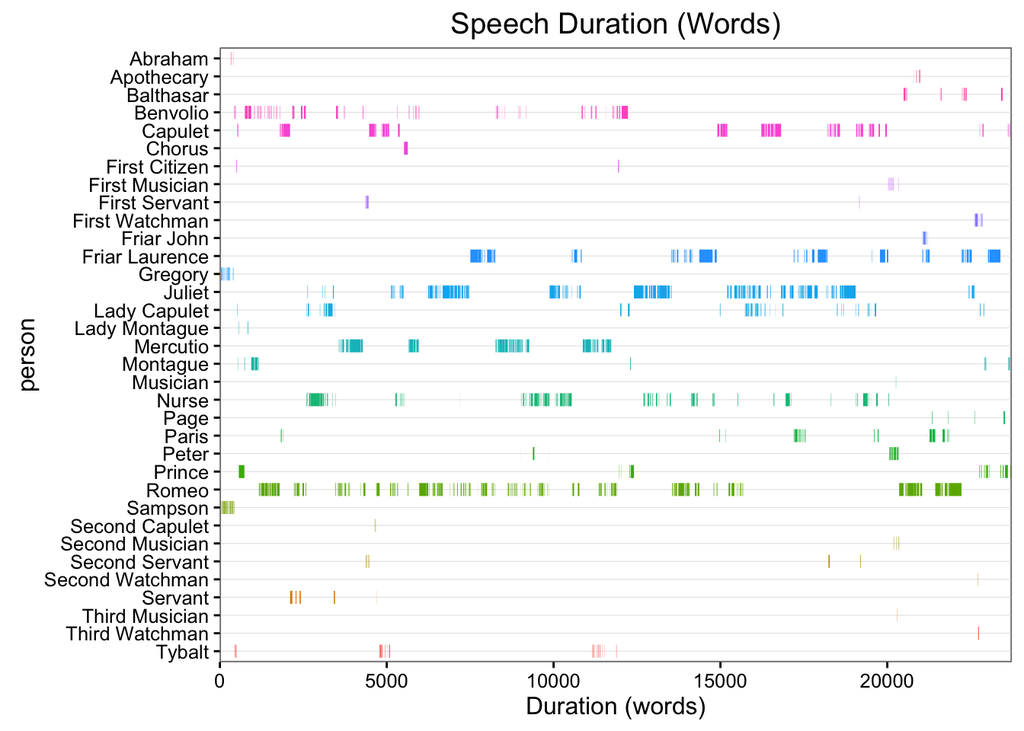

```r
plot(dat)
```

```r
# by grouping
dat2 <- with(rajSPLIT, gantt(dialogue, list(fam.aff, sex)))
head(dat2, 12)
```

```
##    fam.aff_sex   n start end
## 1        cap_m 327     0 327
## 2       mont_m   8   327 335
## 3        cap_m   6   335 341
## 4       mont_m   8   341 349
## 5        cap_m  32   349 381
## 6       mont_m   4   381 385
## 7        cap_m  16   385 401
## 8       mont_m   2   401 403
## 9        cap_m  14   403 417
## 10      mont_m   2   417 419
## 11       cap_m  10   419 429
## 12      mont_m  12   429 441
```

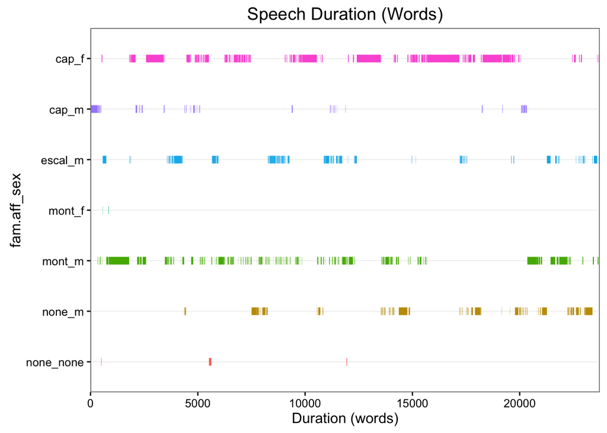

```r
plot(dat2)
```

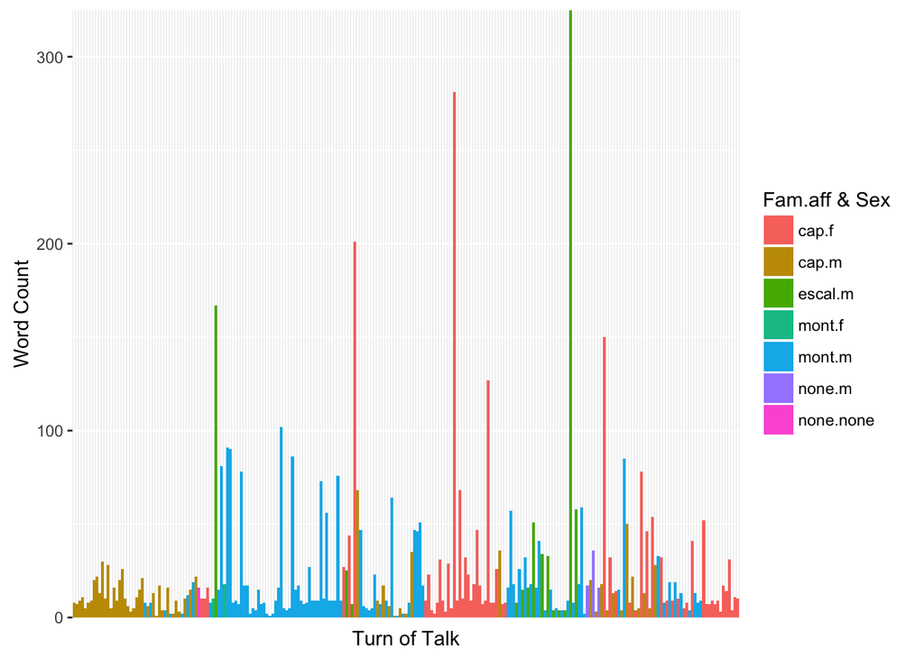

```r
# ToT plots
tot_plot(mraja1, "dialogue", grouping.var = c("fam.aff","sex"), tot = FALSE)
```